# UK Meteorological & Climate Data

Author

Jo Hardin

Published

October 21, 2025

```r
library(tidyverse) # ggplot, lubridate, dplyr, stringr, readr...
library(praise)
library(shiny)
```

## The Data

This week we’re exploring [historic meteorological data](https://www.metoffice.gov.uk/research/climate/maps-and-data/historic-station-data) from the [UK Met Office](https://www.metoffice.gov.uk/).

The UK Met Office is the United Kingdom’s national weather and climate service, providing forecasts, severe weather warnings, and climate science expertise. It helps people, businesses, and governments make informed decisions to stay safe and plan for the future. It was first established in 1854, making it one of the oldest weather services in the world.

Data has been scraped straight from the Met Office website and cleaned in a basic way. The few flags for “estimated” data and changing sunlight monitoring techniques have been removed for simplicity, but are available from the raw data. Also available is simple site metadata which includes the opening date and [latitude and longitude](https://epsg.io/4326) of each station.

> Monthly Historical information for 37 UK Meteorological Stations. Most go back to the early 1900s, but some go back as far as 1853. Station data files are updated on a rolling monthly basis, around 10 days after the end of the month. No allowances have been made for small site changes and developments in instrumentation.

```r
historic_station_met <- readr::read_csv('https://raw.githubusercontent.com/rfordatascience/tidytuesday/main/data/2025/2025-10-21/historic_station_met.csv')
station_meta <- readr::read_csv('https://raw.githubusercontent.com/rfordatascience/tidytuesday/main/data/2025/2025-10-21/station_meta.csv')
```

## Spiral plot

### High temperature (in Aberporth)

```r
month_length <- c(31, 28, 31, 30, 31, 30,
                  31, 31, 30, 31, 30, 31)

month_breaks <- cumsum(month_length) - 30
base_grey <- "grey28"

year_annotations <- list(
  year = c(1960, 1980, 2000, 2020),
  x = rep(3, 4),
  y = ymd(paste(c(1960, 1980, 2000, 2020), "01", "01", sep = "-"))
)
```

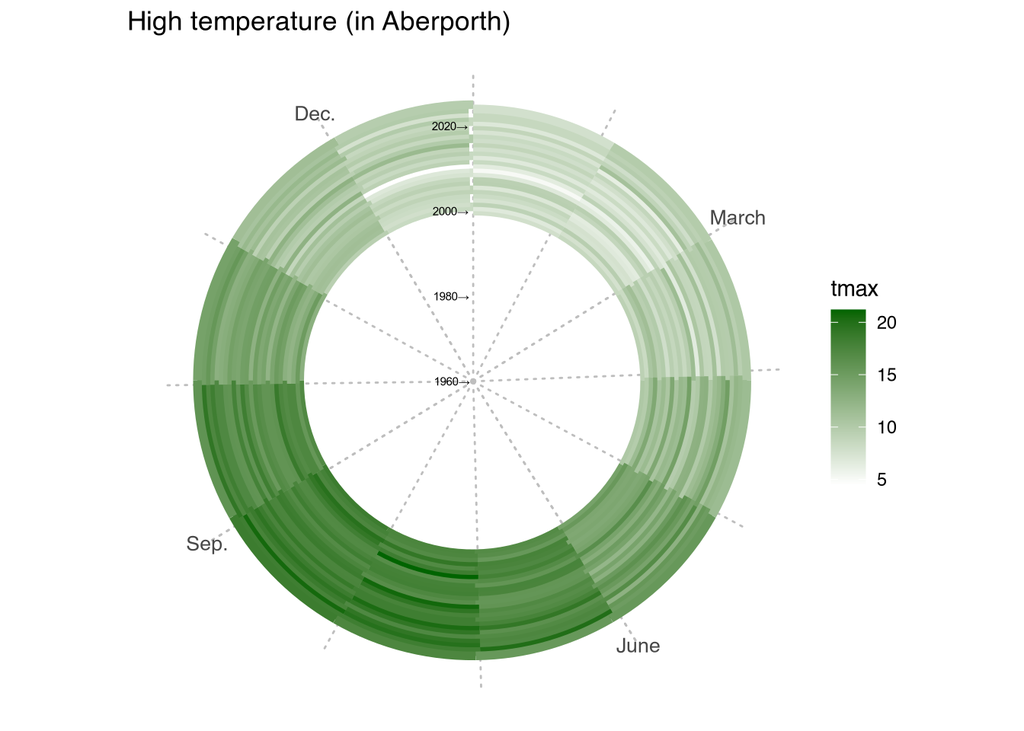

```r
historic_station_met |>
  filter(station == "aberporth") |>
  filter(year >= 2000) |>
  mutate(date = ymd(paste(year, month, "01", sep = "-")),
         day_of_year = yday(date),
         # Handle December specially - extend to end of year instead of next year
         ymd_month = if_else(month == 12,
                             ymd(paste(year, "12", "31", sep = "-")),
                             date %m+% months(1)),
         day_month = yday(ymd_month)) |>
  ggplot() +
  geom_segment(aes(x = day_of_year, xend = day_month,
                   y = date, yend = ymd_month, color = tmax), linewidth = 2) +
  scale_color_gradient(low = "white", high = "darkgreen") +
  annotate("text",
           label = paste0(year_annotations$year, "\u2192"),
           x = year_annotations$x,
           y = year_annotations$y,
           family = "Arial",
           size = 2, hjust = c(1.1, 1.2, 1.3, 1.4)) +#, hjust = 0.15) +

  coord_polar() +
  theme_void() +
  scale_x_continuous(minor_breaks = month_breaks,
                     breaks = month_breaks[c(3, 6, 9, 12)],
                     labels = c("March", "June", "Sep.", "Dec.")) +
  theme(
    plot.background = element_rect(color = NA, fill = "white"),
    panel.grid.major.x = element_line(color = "grey", size = .5, linetype = "dotted"),
    panel.grid.minor.x = element_line(color = "grey", size = .5, linetype = "dotted"),
    axis.text.x = element_text(color = base_grey, size = 10)
  ) +
  labs(title = "High temperature (in Aberporth)")
```

### Low temperature (in Aberporth)

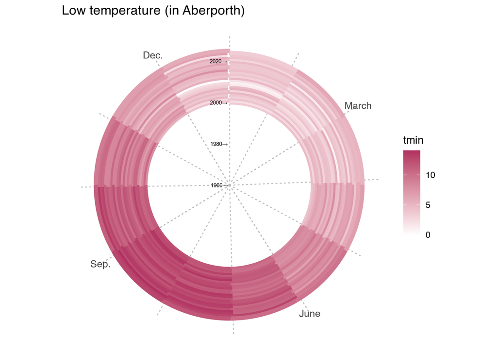

```r
historic_station_met |>
  filter(station == "aberporth") |>
  filter(year >= 2000) |>
  mutate(date = ymd(paste(year, month, "01", sep = "-")),
         day_of_year = yday(date),
         # Handle December specially - extend to end of year instead of next year
         ymd_month = if_else(month == 12,
                             ymd(paste(year, "12", "31", sep = "-")),
                             date %m+% months(1)),
         day_month = yday(ymd_month)) |>
  ggplot() +
  geom_segment(aes(x = day_of_year, xend = day_month,
                   y = date, yend = ymd_month, color = tmin), linewidth = 2) +
  scale_color_gradient(low = "white", high = "maroon") +
  annotate("text",
           label = paste0(year_annotations$year, "\u2192"),
           x = year_annotations$x,
           y = year_annotations$y,
           family = "Arial",
           size = 2, hjust = c(1.1, 1.2, 1.3, 1.4)) +#, hjust = 0.15) +

  coord_polar() +
  theme_void() +
  scale_x_continuous(minor_breaks = month_breaks,
                     breaks = month_breaks[c(3, 6, 9, 12)],
                     labels = c("March", "June", "Sep.", "Dec.")) +
  theme(
    plot.background = element_rect(color = NA, fill = "white"),
    panel.grid.major.x = element_line(color = "grey", size = .5, linetype = "dotted"),
    panel.grid.minor.x = element_line(color = "grey", size = .5, linetype = "dotted"),
    axis.text.x = element_text(color = base_grey, size = 10)
  ) +
  labs(title = "Low temperature (in Aberporth)")
```

### Rain (in Aberporth)

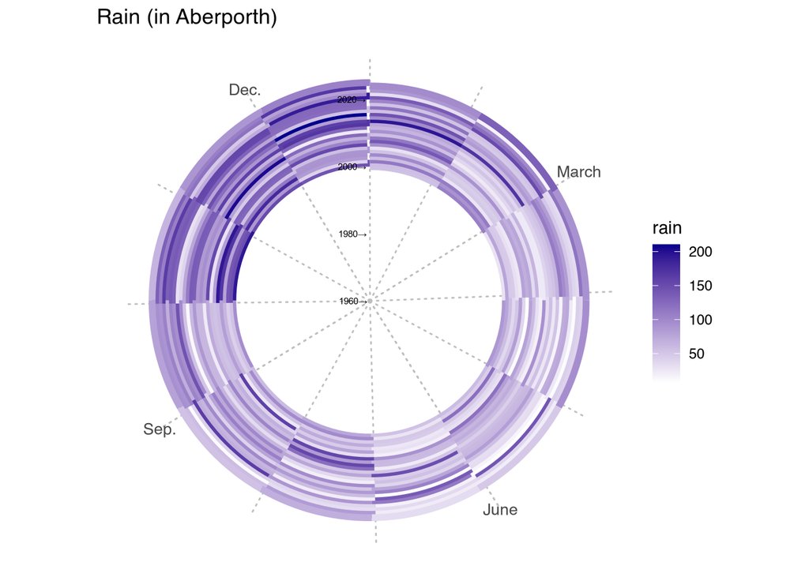

```r
historic_station_met |>
  filter(station == "aberporth") |>
  filter(year >= 2000) |>
  mutate(date = ymd(paste(year, month, "01", sep = "-")),
         day_of_year = yday(date),
         # Handle December specially - extend to end of year instead of next year
         ymd_month = if_else(month == 12,
                             ymd(paste(year, "12", "31", sep = "-")),
                             date %m+% months(1)),
         day_month = yday(ymd_month)) |>
  ggplot() +
  geom_segment(aes(x = day_of_year, xend = day_month,
                   y = date, yend = ymd_month, color = rain), linewidth = 2) +
  scale_color_gradient(low = "white", high = "darkblue") +
  annotate("text",
           label = paste0(year_annotations$year, "\u2192"),
           x = year_annotations$x,
           y = year_annotations$y,
           family = "Arial",
           size = 2, hjust = c(1.1, 1.2, 1.3, 1.4)) +#, hjust = 0.15) +

  coord_polar() +
  theme_void() +
  scale_x_continuous(minor_breaks = month_breaks,
                     breaks = month_breaks[c(3, 6, 9, 12)],
                     labels = c("March", "June", "Sep.", "Dec.")) +
  theme(
    plot.background = element_rect(color = NA, fill = "white"),
    panel.grid.major.x = element_line(color = "grey", size = .5, linetype = "dotted"),
    panel.grid.minor.x = element_line(color = "grey", size = .5, linetype = "dotted"),
    axis.text.x = element_text(color = base_grey, size = 10)
  ) +
  labs(title = "Rain (in Aberporth)")
```

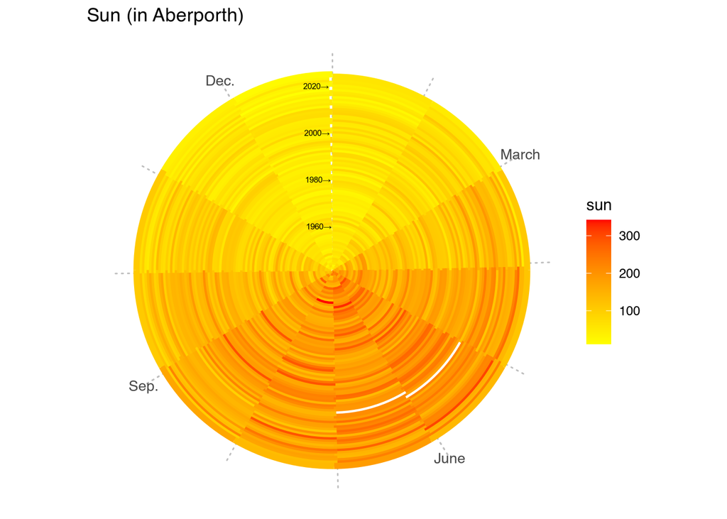

```r
historic_station_met |>
  filter(station == "aberporth") |>
  mutate(date = ymd(paste(year, month, "01", sep = "-")),
         day_of_year = yday(date),
         # Handle December specially - extend to end of year instead of next year
         ymd_month = if_else(month == 12,
                             ymd(paste(year, "12", "31", sep = "-")),
                             date %m+% months(1)),
         day_month = yday(ymd_month)) |>
  ggplot() +
  geom_segment(aes(x = day_of_year, xend = day_month,
                   y = date, yend = ymd_month, color = sun), linewidth = 2) +
  scale_color_gradient(low = "yellow", high = "red", na.value = "white") +
  annotate("text",
           label = paste0(year_annotations$year, "\u2192"),
           x = year_annotations$x,
           y = year_annotations$y,
           family = "Arial",
           size = 2, hjust = c(1.1, 1.2, 1.3, 1.4)) +#, hjust = 0.15) +
  coord_polar() +
  theme_void() +
  scale_x_continuous(minor_breaks = month_breaks,
                     breaks = month_breaks[c(3, 6, 9, 12)],
                     labels = c("March", "June", "Sep.", "Dec.")) +
  theme(
    plot.background = element_rect(color = NA, fill = "white"),
    panel.grid.major.x = element_line(color = "grey", size = .5, linetype = "dotted"),
    panel.grid.minor.x = element_line(color = "grey", size = .5, linetype = "dotted"),
    axis.text.x = element_text(color = base_grey, size = 10)
  ) +
  labs(title = "Sun (in Aberporth)")
```

Sadly, plotly won’t work with `coord_polar()`. So we can’t create a pull down menu for the station. We could if we used shiny, but that isn’t in the cards for today.

```r
praise()
```

```
[1] "You are stylish!"
```

```r
praise()
```

```
[1] "You are cat's meow!"
```